# Communicate Data Findings: Loans Data Exploratory Analysis

### *by `Owhonda Moses`*

- Introduction
- Preliminary Wrangling
- Univariate Exploration
- Bivariate Exploration
- Multivariate Exploration
- Conclusions

## Introduction

> In this project, we will be performing Exploratory Data Analysis on a data set from Prosper, an American marketplace lending platform, with over $9 billion in funded loans.

Our data set contains 113,937 loans with 81 variables on each loan, including loan amount, borrower rate (or interest rate), current loan status, borrower income, and many others. The analysis is structured, going from simple univariate relationships up through multivariate relationships to summarize the characteristics of features that can affect the annual percentage rate and outcome of a loan.

## Preliminary Wrangling

```python
# Import all packages and set plots to be embedded inline
import numpy as np
import pandas as pd
import matplotlib.pyplot as plt
import seaborn as sns

%matplotlib inline
import warnings
warnings.filterwarnings('ignore')
```

```python
# Load in the dataset into a pandas dataframe
df_loans = pd.read_csv('prosperLoanData.csv')
```

```python
# Preview data statistics
print(df_loans.shape)
print(df_loans.info())
```

```
(113937, 81)
<class 'pandas.core.frame.DataFrame'>
RangeIndex: 113937 entries, 0 to 113936
Data columns (total 81 columns):
 #   Column                               Non-Null Count   Dtype
---  ------                               --------------   -----
 0   ListingKey                           113937 non-null  object
 1   ListingNumber                        113937 non-null  int64
 2   ListingCreationDate                  113937 non-null  object
 3   CreditGrade                          28953 non-null   object
 4   Term                                 113937 non-null  int64
 5   LoanStatus                           113937 non-null  object
 6   ClosedDate                           55089 non-null   object
 7   BorrowerAPR                          113912 non-null  float64
 8   BorrowerRate                         113937 non-null  float64
```

[output cut: 75 more lines]

```python
# Preview the dataset
df_loans.head()
```

|  | ListingKey | ListingNumber | ListingCreationDate | CreditGrade | Term | LoanStatus | ClosedDate | BorrowerAPR | BorrowerRate | LenderYield | ... | LP_ServiceFees | LP_CollectionFees | LP_GrossPrincipalLoss | LP_NetPrincipalLoss | LP_NonPrincipalRecoverypayments | PercentFunded | Recommendations | InvestmentFromFriendsCount | InvestmentFromFriendsAmount | Investors |
| --- | --- | --- | --- | --- | --- | --- | --- | --- | --- | --- | --- | --- | --- | --- | --- | --- | --- | --- | --- | --- | --- |
| 0 | 1021339766868145413AB3B | 193129 | 2007-08-26 19:09:29.263000000 | C | 36 | Completed | 2009-08-14 00:00:00 | 0.16516 | 0.1580 | 0.1380 | ... | -133.18 | 0.0 | 0.0 | 0.0 | 0.0 | 1.0 | 0 | 0 | 0.0 | 258 |
| 1 | 10273602499503308B223C1 | 1209647 | 2014-02-27 08:28:07.900000000 | NaN | 36 | Current | NaN | 0.12016 | 0.0920 | 0.0820 | ... | 0.00 | 0.0 | 0.0 | 0.0 | 0.0 | 1.0 | 0 | 0 | 0.0 | 1 |
| 2 | 0EE9337825851032864889A | 81716 | 2007-01-05 15:00:47.090000000 | HR | 36 | Completed | 2009-12-17 00:00:00 | 0.28269 | 0.2750 | 0.2400 | ... | -24.20 | 0.0 | 0.0 | 0.0 | 0.0 | 1.0 | 0 | 0 | 0.0 | 41 |
| 3 | 0EF5356002482715299901A | 658116 | 2012-10-22 11:02:35.010000000 | NaN | 36 | Current | NaN | 0.12528 | 0.0974 | 0.0874 | ... | -108.01 | 0.0 | 0.0 | 0.0 | 0.0 | 1.0 | 0 | 0 | 0.0 | 158 |
| 4 | 0F023589499656230C5E3E2 | 909464 | 2013-09-14 18:38:39.097000000 | NaN | 36 | Current | NaN | 0.24614 | 0.2085 | 0.1985 | ... | -60.27 | 0.0 | 0.0 | 0.0 | 0.0 | 1.0 | 0 | 0 | 0.0 | 20 |

5 rows × 81 columns

Since this project is primarily focused on visualization skills, I will skip the outlining of wrangling steps as well as the `define`-`code`-`step` process.

```python
# Make a copy of the dataframe before wrangling
loans = df_loans.copy()
```

```python
# Select variables of interest for our analysis & subset dataframe
loans = loans[['Term', 'LoanStatus', 'BorrowerAPR', 'ProsperScore', 'ListingCategory (numeric)', 'EmploymentStatus',
            'CreditScoreRangeLower', 'CreditScoreRangeUpper', 'OpenCreditLines', 'TradesNeverDelinquent (percentage)',
            'RevolvingCreditBalance','BankcardUtilization', 'TotalTrades', 'IncomeRange', 'LoanOriginalAmount']]

# Rename 'ListingCategory (numeric)' and 'TradesNeverDelinquent (percentage)' columns
loans = loans.rename(columns = {'ListingCategory (numeric)':'ListingCategory',
                                'TradesNeverDelinquent (percentage)':'TradesNeverDelinquent'})
```

```python
# Preview data statistics of subsetted dataframe
print(loans.shape)
print(loans.info())
```

```
(113937, 15)
<class 'pandas.core.frame.DataFrame'>
RangeIndex: 113937 entries, 0 to 113936
Data columns (total 15 columns):
 #   Column                  Non-Null Count   Dtype
---  ------                  --------------   -----
 0   Term                    113937 non-null  int64
 1   LoanStatus              113937 non-null  object
 2   BorrowerAPR             113912 non-null  float64
 3   ProsperScore            84853 non-null   float64
 4   ListingCategory         113937 non-null  int64
 5   EmploymentStatus        111682 non-null  object
 6   CreditScoreRangeLower   113346 non-null  float64
 7   CreditScoreRangeUpper   113346 non-null  float64
 8   OpenCreditLines         106333 non-null  float64
 9   TradesNeverDelinquent   106393 non-null  float64
 10  RevolvingCreditBalance  106333 non-null  float64
 11  BankcardUtilization     106333 non-null  float64
 12  TotalTrades             106393 non-null  float64
 13  IncomeRange             113937 non-null  object
 14  LoanOriginalAmount      113937 non-null  int64
dtypes: float64(9), int64(3), object(3)
memory usage: 13.0+ MB
None
```

```python
# Check summary statistics
loans.describe()
```

|  | Term | BorrowerAPR | ProsperScore | ListingCategory | CreditScoreRangeLower | CreditScoreRangeUpper | OpenCreditLines | TradesNeverDelinquent | RevolvingCreditBalance | BankcardUtilization | TotalTrades | LoanOriginalAmount |
| --- | --- | --- | --- | --- | --- | --- | --- | --- | --- | --- | --- | --- |
| count | 113937.000000 | 113912.000000 | 84853.000000 | 113937.000000 | 113346.000000 | 113346.000000 | 106333.000000 | 106393.000000 | 1.063330e+05 | 106333.000000 | 106393.000000 | 113937.00000 |
| mean | 40.830248 | 0.218828 | 5.950067 | 2.774209 | 685.567731 | 704.567731 | 9.260164 | 0.885897 | 1.759871e+04 | 0.561309 | 23.230034 | 8337.01385 |
| std | 10.436212 | 0.080364 | 2.376501 | 3.996797 | 66.458275 | 66.458275 | 5.022644 | 0.148179 | 3.293640e+04 | 0.317918 | 11.871311 | 6245.80058 |
| min | 12.000000 | 0.006530 | 1.000000 | 0.000000 | 0.000000 | 19.000000 | 0.000000 | 0.000000 | 0.000000e+00 | 0.000000 | 0.000000 | 1000.00000 |
| 25% | 36.000000 | 0.156290 | 4.000000 | 1.000000 | 660.000000 | 679.000000 | 6.000000 | 0.820000 | 3.121000e+03 | 0.310000 | 15.000000 | 4000.00000 |
| 50% | 36.000000 | 0.209760 | 6.000000 | 1.000000 | 680.000000 | 699.000000 | 9.000000 | 0.940000 | 8.549000e+03 | 0.600000 | 22.000000 | 6500.00000 |
| 75% | 36.000000 | 0.283810 | 8.000000 | 3.000000 | 720.000000 | 739.000000 | 12.000000 | 1.000000 | 1.952100e+04 | 0.840000 | 30.000000 | 12000.00000 |
| max | 60.000000 | 0.512290 | 11.000000 | 20.000000 | 880.000000 | 899.000000 | 54.000000 | 1.000000 | 1.435667e+06 | 5.950000 | 126.000000 | 35000.00000 |

I am interested in loans with a `ProsperScore` value. These loans also happen to have originated after July 2009.

```python
# Select only entries with ProsperScore values in dataframe
loans = loans[loans['ProsperScore'].notna()]
loans.info()
```

```
<class 'pandas.core.frame.DataFrame'>
Int64Index: 84853 entries, 1 to 113936
Data columns (total 15 columns):
 #   Column                  Non-Null Count  Dtype
---  ------                  --------------  -----
 0   Term                    84853 non-null  int64
 1   LoanStatus              84853 non-null  object
 2   BorrowerAPR             84853 non-null  float64
 3   ProsperScore            84853 non-null  float64
 4   ListingCategory         84853 non-null  int64
 5   EmploymentStatus        84853 non-null  object
 6   CreditScoreRangeLower   84853 non-null  float64
 7   CreditScoreRangeUpper   84853 non-null  float64
 8   OpenCreditLines         84853 non-null  float64
 9   TradesNeverDelinquent   84853 non-null  float64
 10  RevolvingCreditBalance  84853 non-null  float64
 11  BankcardUtilization     84853 non-null  float64
 12  TotalTrades             84853 non-null  float64
 13  IncomeRange             84853 non-null  object
 14  LoanOriginalAmount      84853 non-null  int64
dtypes: float64(9), int64(3), object(3)
memory usage: 10.4+ MB
```

```python
# Preview dataset head
loans.head(2)
```

|  | Term | LoanStatus | BorrowerAPR | ProsperScore | ListingCategory | EmploymentStatus | CreditScoreRangeLower | CreditScoreRangeUpper | OpenCreditLines | TradesNeverDelinquent | RevolvingCreditBalance | BankcardUtilization | TotalTrades | IncomeRange | LoanOriginalAmount |
| --- | --- | --- | --- | --- | --- | --- | --- | --- | --- | --- | --- | --- | --- | --- | --- |
| 1 | 36 | Current | 0.12016 | 7.0 | 2 | Employed | 680.0 | 699.0 | 14.0 | 1.00 | 3989.0 | 0.21 | 29.0 | $50,000-74,999 | 10000 |
| 3 | 36 | Current | 0.12528 | 9.0 | 16 | Employed | 800.0 | 819.0 | 5.0 | 0.76 | 1444.0 | 0.04 | 26.0 | $25,000-49,999 | 10000 |

IncomeRange has values of `'$0'` and `'Not employed'`. We will check the `EmploymentStatus` for borrowers with an `IncomeRange` of `'$0'`

```python
# Return Employment status of entries with an IncomeRange of $0
print(loans[loans.IncomeRange == '$0'].EmploymentStatus.values)
```

```
['Full-time' 'Employed' 'Self-employed' 'Self-employed' 'Employed'
 'Self-employed' 'Full-time' 'Employed' 'Self-employed' 'Full-time'
 'Self-employed' 'Full-time' 'Part-time' 'Part-time' 'Full-time'
 'Full-time' 'Employed' 'Self-employed' 'Self-employed' 'Self-employed'
 'Full-time' 'Part-time' 'Part-time' 'Employed' 'Employed' 'Full-time'
 'Full-time' 'Full-time' 'Self-employed' 'Employed' 'Full-time' 'Employed'
 'Part-time' 'Full-time' 'Full-time' 'Self-employed' 'Full-time'
 'Self-employed' 'Full-time' 'Employed' 'Self-employed' 'Self-employed'
 'Self-employed' 'Self-employed' 'Employed']
```

We see that all borrowers with `'$0'` `IncomeRange` are employed in someway. For consistency, we would change the **employment status** of these entries to `'Not employed'` and change the `'Not employed'` in `IncomeRange` to `'$0'`

```python
# Get the indexes of entries with Income range of '$0' and 'Not employed'
not_employed_status = loans[loans.IncomeRange == '$0'].EmploymentStatus.index
not_employed_income = loans[loans.IncomeRange == 'Not employed'].IncomeRange.index

# Change employment status to 'Not employed' for '$0' income range
# Change 'Not employed' income range to '$0'
loans.loc[not_employed_status, 'EmploymentStatus'] = 'Not employed'
loans.loc[not_employed_income, 'IncomeRange'] = '$0'
```

```python
# Confirm changes to dataset
loans[loans.IncomeRange == '$0'].head()
```

|  | Term | LoanStatus | BorrowerAPR | ProsperScore | ListingCategory | EmploymentStatus | CreditScoreRangeLower | CreditScoreRangeUpper | OpenCreditLines | TradesNeverDelinquent | RevolvingCreditBalance | BankcardUtilization | TotalTrades | IncomeRange | LoanOriginalAmount |
| --- | --- | --- | --- | --- | --- | --- | --- | --- | --- | --- | --- | --- | --- | --- | --- |
| 100 | 36 | Chargedoff | 0.35356 | 3.0 | 13 | Not employed | 720.0 | 739.0 | 3.0 | 1.00 | 5641.0 | 0.22 | 4.0 | $0 | 4000 |
| 125 | 36 | Current | 0.35643 | 5.0 | 7 | Not employed | 640.0 | 659.0 | 7.0 | 1.00 | 10425.0 | 0.98 | 21.0 | $0 | 5000 |
| 170 | 36 | Completed | 0.28851 | 5.0 | 7 | Not employed | 760.0 | 779.0 | 7.0 | 1.00 | 33934.0 | 0.88 | 15.0 | $0 | 10000 |
| 186 | 36 | Chargedoff | 0.35797 | 5.0 | 2 | Not employed | 660.0 | 679.0 | 3.0 | 0.44 | 3029.0 | 0.53 | 36.0 | $0 | 4000 |
| 335 | 36 | Completed | 0.35797 | 3.0 | 7 | Not employed | 760.0 | 779.0 | 1.0 | 1.00 | 0.0 | 0.00 | 3.0 | $0 | 2000 |

```python
# Check unique values of Income range
loans.IncomeRange.value_counts()
```

```
$50,000-74,999    25627
$25,000-49,999    24175
$100,000+         15205
$75,000-99,999    14498
$1-24,999          4654
$0                  694
Name: IncomeRange, dtype: int64
```

```python
# Convert CreditScore columns to int datatype
loans['CreditScoreRangeLower'] = loans['CreditScoreRangeLower'].astype(int)
loans['CreditScoreRangeUpper'] = loans['CreditScoreRangeUpper'].astype(int)

# Combine CreditScoreRangeLower & CreditScoreRangeUpper into one column
# Drop CreditScoreRangeLower & CreditScoreRangeUpper columns from dataframe
loans['CreditScoreRange'] = loans['CreditScoreRangeLower'].astype(str)+'-'+loans['CreditScoreRangeUpper'].astype(str)
loans = loans.drop(['CreditScoreRangeLower', 'CreditScoreRangeUpper'], axis=1)
```

```python
# Confirm changes
print(loans.CreditScoreRange.unique())
loans.head(1)
```

```
['680-699' '800-819' '740-759' '700-719' '820-839' '640-659' '660-679'
 '720-739' '760-779' '780-799' '600-619' '620-639' '840-859' '860-879'
 '880-899']
```

|  | Term | LoanStatus | BorrowerAPR | ProsperScore | ListingCategory | EmploymentStatus | OpenCreditLines | TradesNeverDelinquent | RevolvingCreditBalance | BankcardUtilization | TotalTrades | IncomeRange | LoanOriginalAmount | CreditScoreRange |
| --- | --- | --- | --- | --- | --- | --- | --- | --- | --- | --- | --- | --- | --- | --- |
| 1 | 36 | Current | 0.12016 | 7.0 | 2 | Employed | 14.0 | 1.0 | 3989.0 | 0.21 | 29.0 | $50,000-74,999 | 10000 | 680-699 |

```python
# Convert CreditScoreRange, ProsperScore and Income range into ordered category datatypes
# Convert Term, Loan Status, Listing Category and Employment Status into category datatypes

ordinal_var_dict = {'ProsperScore': [1.0, 2.0, 3.0, 4.0, 5.0, 6.0, 7.0, 8.0, 9.0, 10.0, 11.0],
                   'IncomeRange': ['$0', '$1-24,999', '$25,000-49,999', '$50,000-74,999', '$75,000-99,999', '$100,000+'],
                   'CreditScoreRange': ['600-619', '620-639', '640-659', '660-679', '680-699', '700-719', '720-739', '740-759',
                                       '760-779', '780-799', '800-819', '820-839', '840-859', '860-879', '880-899']}
for var in ordinal_var_dict:
    ordered_var = pd.api.types.CategoricalDtype(ordered=True, categories=ordinal_var_dict[var])
    loans[var] = loans[var].astype(ordered_var)

loans['Term'] = loans['Term'].astype('category')
loans['LoanStatus'] = loans['LoanStatus'].astype('category')
loans['ListingCategory'] = loans['ListingCategory'].astype('category')
loans['EmploymentStatus'] = loans['EmploymentStatus'].astype('category')
```

```python
# Confirm datatype changes & check dimensions of dataset
print(loans.shape)
print(loans.dtypes)
```

```
(84853, 14)
Term                      category
LoanStatus                category
BorrowerAPR                float64
ProsperScore              category
ListingCategory           category
EmploymentStatus          category
OpenCreditLines            float64
TradesNeverDelinquent      float64
RevolvingCreditBalance     float64
BankcardUtilization        float64
TotalTrades                float64
IncomeRange               category
LoanOriginalAmount           int64
CreditScoreRange          category
dtype: object
```

### What is the structure of your dataset?

> There are originally 113,937 loans in the dataset with 81 features on each loan entry. Most variables in the dataset are numeric in nature, with a few ordinal factor variables. However, since I will be focused on loans with a ProsperScore, i.e loans originated after July 2009, the dataset has now been trimmed down to 84,853 loans with 14 variables of interest.

### What is/are the main feature(s) of interest in your dataset?

> I'm interested in figuring out what features are best for predicting a loan's annual percentage rate (APR) and outcome status. Key features for my analysis are `CreditScoreRange` and `BorrowerAPR`

### What features in the dataset do you think will help support your investigation into your feature(s) of interest?

> A number of features in the dataset could affect the APR and outcome of a loan to varying degrees, but in addition to my main features of interest, I will also investigate the following 12 features:
> - `'Term'` `'LoanStatus'` `'ProsperScore'` `'ListingCategory'` `'EmploymentStatus'` `'OpenCreditLines'` `'TradesNeverDelinquent'` `RevolvingCreditBalance` `'BankcardUtilization'` `'TotalTrades'` `'IncomeRange'` `'LoanOriginalAmount'.`

## Univariate Exploration

> In this section, I will investigate distributions of individual variables. I'll start by looking at the distribution of the main feature of interest: `CreditScoreRange.`

What is the distribution of Credit Score ranges?

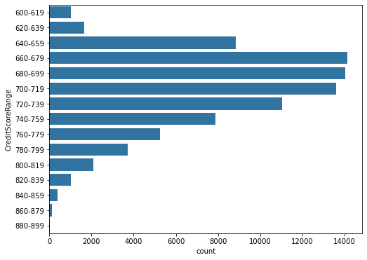

```python
# Bar plot of credit score ranges
plt.figure(figsize=(8,6))
base_color = sns.color_palette()[0]
sns.countplot(data=loans, y='CreditScoreRange', color=base_color);
```

We see that the vast majority of borrowers had a credit score between 660 - 719 with the most frequent range between 660 - 679. There is a slight right skew in the distribution with higher credit scores having less borrowers.

The next main feature of interest is the `BorrowerAPR` (Annual Percentage Rate) which represents the total cost of a loan to a borrower. Let us see the distribution of BorrowerAPR.

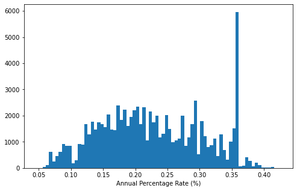

```python
# Plot a histogram to show distribution of Borrower APR
plt.figure(figsize=(8, 5))
bin_size = 0.005
bins = np.arange(loans.BorrowerAPR.min(), loans.BorrowerAPR.max()+bin_size, bin_size)

plt.hist(data=loans, x='BorrowerAPR', bins=bins)
plt.xlabel('Annual Percentage Rate (%)');
```

OpenCreditLines allows a borrower to access credit repeatedly up to a specific maximum limit. Let us see the distribution of open credit lines.

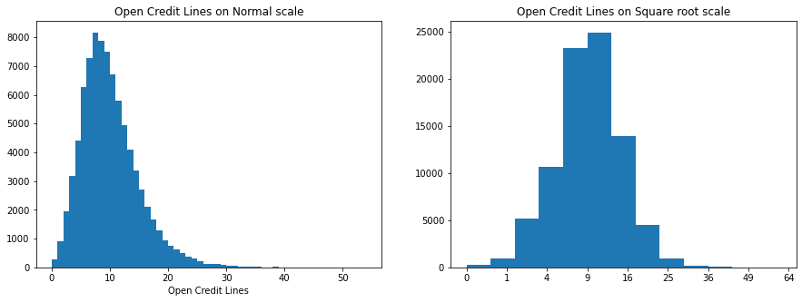

```python
# Plot a histogram to show distribution of Open credit lines on a normal scale
plt.figure(figsize=(15, 5))
plt.subplot(1, 2, 1)
bin_size = 1
bins = np.arange(0, 54+bin_size, bin_size)
plt.hist(data=loans, x='OpenCreditLines', bins=bins)
plt.xlabel('Open Credit Lines')
plt.title('Open Credit Lines on Normal scale');

# Plot credit lines on a square root scale
def sqrt_trans(x, inverse=False):
    if not inverse:
        return np.sqrt(x)
    else:
        return x ** 2

plt.subplot(1, 2, 2)
bin_size = 0.6
bin_edges = np.arange(0, sqrt_trans(loans.OpenCreditLines.max())+bin_size, bin_size)
plt.hist(loans.OpenCreditLines.apply(sqrt_trans), bins=bin_edges)
tick_locs = np.arange(0, sqrt_trans(loans.OpenCreditLines.max())+1, 1)
plt.xticks(tick_locs, sqrt_trans(tick_locs, inverse=True).astype(int))
plt.title('Open Credit Lines on Square root scale');
```

OpenCreditLines is an interesting variable for loan prediction and so I subplotted a transformed scale for better insight. On the normal scale, we see a uni-modal and right-skewed distribution with the peak between 8-10. Lesser frequencies are seen in increasing count of open credit lines. On the square root scale however, the distribution does not differ much from the standard scale but appears roughly normal.

Moving on, let us examine the distribution of Revolving credit balance as well as Bankcard utilization, which is the percentage of a borrower's total credit currently being used.

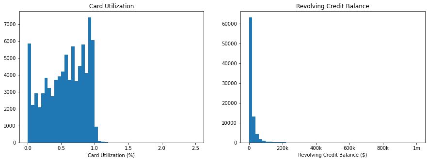

```python
# Plot a histogram to show distribution of Bankcard utilization
plt.figure(figsize=(15, 5))
plt.subplot(1, 2, 1)
bin_size = 0.05
bins = np.arange(0, 2.5+bin_size, bin_size)
plt.hist(data=loans, x='BankcardUtilization', bins=bins)
plt.xlabel('Card Utilization (%)')
plt.title('Card Utilization');

# Plot a histogram to show distribution of Revolving credit balance
plt.subplot(1, 2, 2)
bin_size = 20000
bins = np.arange(0, loans.RevolvingCreditBalance.max()+bin_size, bin_size)
plt.hist(data=loans, x='RevolvingCreditBalance', bins=bins)
plt.xticks([0, 0.2e6, 0.4e6, 0.6e6, 0.8e6, 1.0e6], [0, '200k', '400k', '600k', '800k', '1m'])
plt.xlabel('Revolving Credit Balance ($)')
plt.title('Revolving Credit Balance');
```

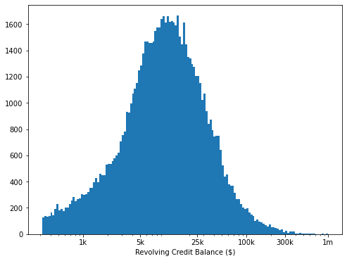

```python
# Let's plot the revolving credit balance on a log scale
plt.figure(figsize=(8,6))
log_bin = 0.025
bins = 10 ** np.arange(2.5, np.log10(loans['RevolvingCreditBalance'].max())+log_bin, log_bin)
plt.hist(data=loans, x='RevolvingCreditBalance', bins=bins)
plt.xscale('log')
plt.xticks([1e3, 5e3, 2.5e4, 0.1e6, 0.3e6, 1.0e6], ['1k', '5k', '25k', '100k', '300k', '1m'])
plt.xlabel('Revolving Credit Balance ($)');
```

TotalTrades describes the activity and status of a borrower's credit account. We will examine it's distribution along with the distributions of LoanOriginalAmount & TradeNeverDelinquent variables.

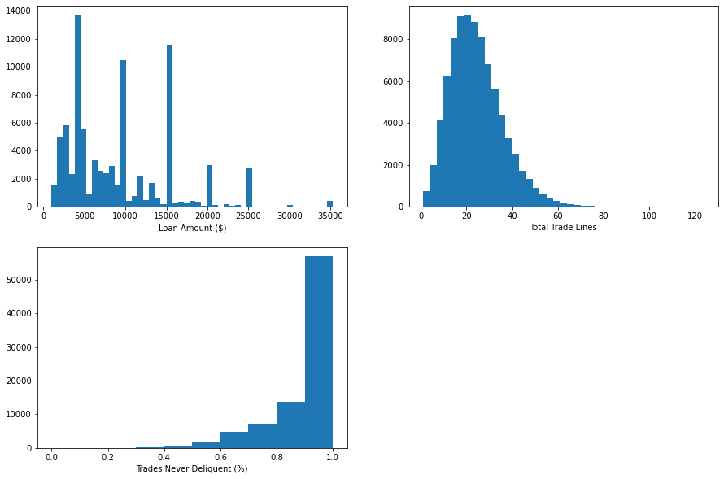

```python
# Plot a histogram to show distribution of Loan amount
plt.figure(figsize=(15, 10))
plt.subplot(2, 2, 1)
bin_size = 700
bins = np.arange(1000, 35000+bin_size, bin_size)
plt.hist(data=loans, x='LoanOriginalAmount', bins=bins)
plt.xlabel('Loan Amount ($)');

# Plot a histogram to show distribution of Total trades
plt.subplot(2, 2, 2)
bin_size = 3
bins = np.arange(1, 122+bin_size, bin_size)
plt.hist(data=loans, x='TotalTrades', bins=bins)
plt.xlabel('Total Trade Lines');

# Plot a histogram to show distribution of Trades never delinquent
plt.subplot(2, 2, 3)
bin_size = 0.1
bins = np.arange(0, 1+bin_size, bin_size)
plt.hist(data=loans, x='TradesNeverDelinquent', bins=bins)
plt.xlabel('Trades Never Deliquent (%)');
```

We see very large spikes in frequency at the bars around 4,000, 9,000 and 15,000; frequency gradually trails off until the next spike. The highest spike is seen between `$4k - $5k` and the least frequency falls between the range of `$26k-34k.` Tradelines however, peak at around 20 and slightly skews to the right with very few credit profiles having more than 80 tradelines, and few having delinquent trades.

Moving on, let us examine the distributions of Term, LoanStatus & ListingCategory variables.

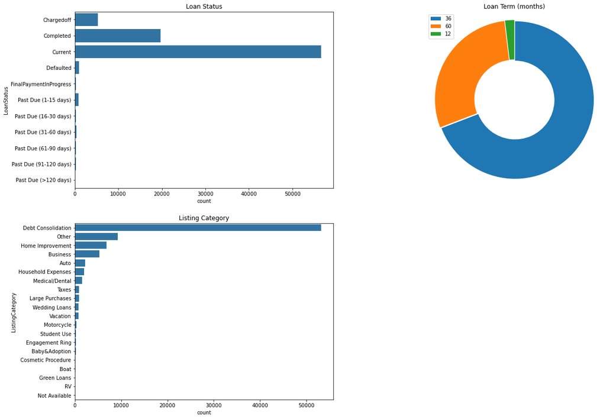

```python
# Plot a vis for the three categorical variables
base_color = sns.color_palette()[0]
plt.figure(figsize=(20,14))
plt.subplot(2, 2, 1)
g = sns.countplot(data=loans, y='LoanStatus', color=base_color)
plt.title('Loan Status');

plt.subplot(2, 2, 2)
term_counts = loans.Term.value_counts()
explode = (0.01, 0.01, 0.01)
plt.pie(term_counts, labels=None, explode=explode, startangle=90, counterclock=False, wedgeprops={'width':.5})
plt.title('Loan Term (months)')
plt.axis('square')
plt.legend(loc=2, labels=term_counts.index);

plt.subplot(2, 2, 3)
# Replace numbers with actual listing categories
loans['ListingCategory'].replace([0, 1, 2, 3, 4, 5, 6, 7, 8, 9, 10, 11, 12, 13, 14, 15, 16, 17, 18, 19, 20], ['Not Available',
                    'Debt Consolidation', 'Home Improvement', 'Business', 'Personal Loan', 'Student Use', 'Auto', 'Other',
                   'Baby&Adoption', 'Boat', 'Cosmetic Procedure', 'Engagement Ring', 'Green Loans', 'Household Expenses',
                   'Large Purchases', 'Medical/Dental', 'Motorcycle', 'RV', 'Taxes', 'Vacation', 'Wedding Loans'], inplace=True)
listing_order = loans.ListingCategory.value_counts().index
sns.countplot(data=loans, y='ListingCategory', color=base_color, order=listing_order)
plt.title('Listing Category');
```

Majority of the loans are currently running and listed under `Debt consolidation`, represented as '1' in the original listing category. Also, most loans in our dataset span 36months. I am now interested in seeing the proportions of the loan status, particularly, Past Due, Defaulted and Charged off loans with and without current loans.

```python
 # To do this let's first create a new column for loan status showing all late loans as 'Past Due'
loans['status'] = loans['LoanStatus'].astype(str)
loans_past = loans[(loans['status'] == 'Past Due (1-15 days)') | (loans['status'] == 'Past Due (31-60 days)')
              | (loans['status'] == 'Past Due (61-90 days)') | (loans['status'] == 'Past Due (91-120 days)')
              | (loans['status'] == 'Past Due (16-30 days)') | (loans['status'] == 'Past Due (>120 days)')].status.index
loans.loc[loans_past, 'status'] = 'Past Due'
```

```python
# Get the length of the longest bar in terms of proportion for all loan status
status_counts = loans.status.value_counts()
n_status = status_counts.sum()
max_count = status_counts[0]
max_prop = max_count / n_status
```

```python
# Create an array of evenly spaced proportions between 0 & max_prop with a step size of 2%
# Create tick_names to be applied to the tick labels using list comprehension
tick_props = np.arange(0, max_prop, 0.02)
tick_names = ['{:0.2f}'.format(v) for v in tick_props]
```

```python
# Next, let us get the entries of loan status excepting current loans
loan_status = loans[(loans['status'] == 'Past Due') | (loans['status'] == 'Chargedoff') | (loans['status'] == 'Defaulted')
                    | (loans['status'] == 'FinalPaymentInProgress') | (loans['status'] == 'Completed')]
```

```python
# Get the maximum proportion of bars
loan_status_count = loan_status.status.value_counts()
n_loan_status = loan_status_count.sum()
max_status_count = loan_status_count[0]
max_props = max_status_count / n_loan_status
```

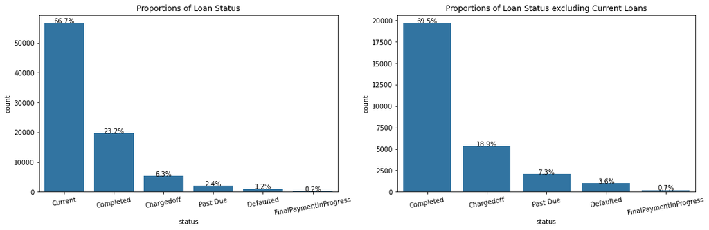

```python
# Plot a barchart showing proportion text on the bars for all loan status
base_color = sns.color_palette()[0]
status_order = status_counts.index
plt.figure(figsize=(18,5))
plt.subplot(1, 2, 1)
sns.countplot(data=loans, x='status', color=base_color, order=status_order)
plt.title('Proportions of Loan Status');

locs, labels = plt.xticks(rotation=10)
for loc, label in zip(locs, labels):
    count = status_counts[label.get_text()]
    pct_string = '{:0.1f}%'.format(100*count/n_status)
    plt.text(loc, count+0.1, pct_string, ha='center', color='black')

# Plot a barchart showing proportion text on the bars for all loan status except current loans
loan_status_order = loan_status_count.index
plt.subplot(1, 2 ,2)
sns.countplot(data=loan_status, x='status', color=base_color, order=loan_status_order)
plt.title('Proportions of Loan Status excluding Current Loans');

tick_props = np.arange(0, max_props, 0.02) #create tick arrays and tick names
tick_names = ['{:0.2f}'.format(v) for v in tick_props]
locs, labels = plt.xticks(rotation=10)
for loc, label in zip(locs, labels):
    count = status_counts[label.get_text()]
    pct_string = '{:0.1f}%'.format(100*count/n_loan_status)
    plt.text(loc, count+0.1, pct_string, ha='center', color='black')
```

About 10% of the loans are either Past Due, Defaulted or Charged off. However, with current loans excluded, we see that the deficient loans now account for about 30% of loans in the dataset.

Next, let us examine the distributions of Income Range, Employment Status and Prosper score variables together

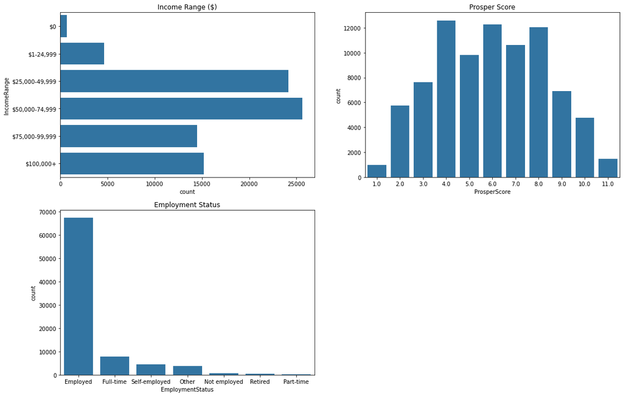

```python
# Plot all three categorical variables together
base_color = sns.color_palette()[0]
plt.figure(figsize=(18,12))
plt.subplot(2, 2, 1)
sns.countplot(data=loans, y='IncomeRange', color=base_color)
plt.title('Income Range ($)');

plt.subplot(2, 2, 2)
sns.countplot(data=loans, x='ProsperScore', color=base_color)
plt.title('Prosper Score');

plt.subplot(2, 2, 3)
employ_order = loans.EmploymentStatus.value_counts().index
sns.countplot(data=loans, x='EmploymentStatus', color=base_color, order=employ_order)
plt.title('Employment Status');
```

Most borrowers are employed and most fall within an income range of `$50,000 - $74,999`, while the unemployed folks with $0 income are among the least borrowers. We can also see that most of the borrowers have a Prosper score of 4.0, successively followed by 6.0 and then 8.0.

### Of the features you investigated, were there any unusual distributions? Did you perform any operations on the data to tidy, adjust, or change the form of the data? If so, why did you do this?

> Revolving credit balance had an unusual distribution considering the range of values while the loan status had too many current loans obscuring the proportion of the other loan status. Excluding the current loans gave clearer proportions, particularly of Past Due, Defaulted & Charged off loans.

## Bivariate Exploration

> In this section, I will investigate relationships between pairs of variables in the data starting with the pairwise correlations present between numeric and categoric features.

```python
# Firstly, let's group variables into numeric & categorical data
num_vars = ['BorrowerAPR', 'OpenCreditLines', 'TradesNeverDelinquent', 'BankcardUtilization', 'TotalTrades',
            'LoanOriginalAmount', 'RevolvingCreditBalance']
cat_vars = ['Term', 'LoanStatus', 'ProsperScore', 'ListingCategory', 'EmploymentStatus', 'IncomeRange', 'CreditScoreRange']
```

How do the numeric variables correlate with each other?

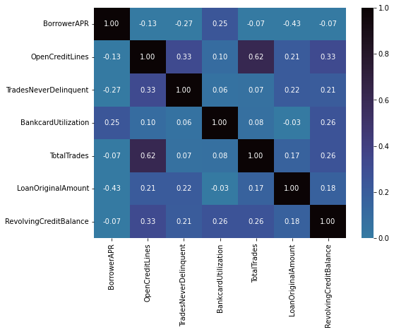

```python
# Correlation plot of numeric data
plt.figure(figsize=(8,6))
sns.heatmap(loans[num_vars].corr(), annot=True, fmt='.2f', cmap='mako_r', center=0, vmin=0);
```

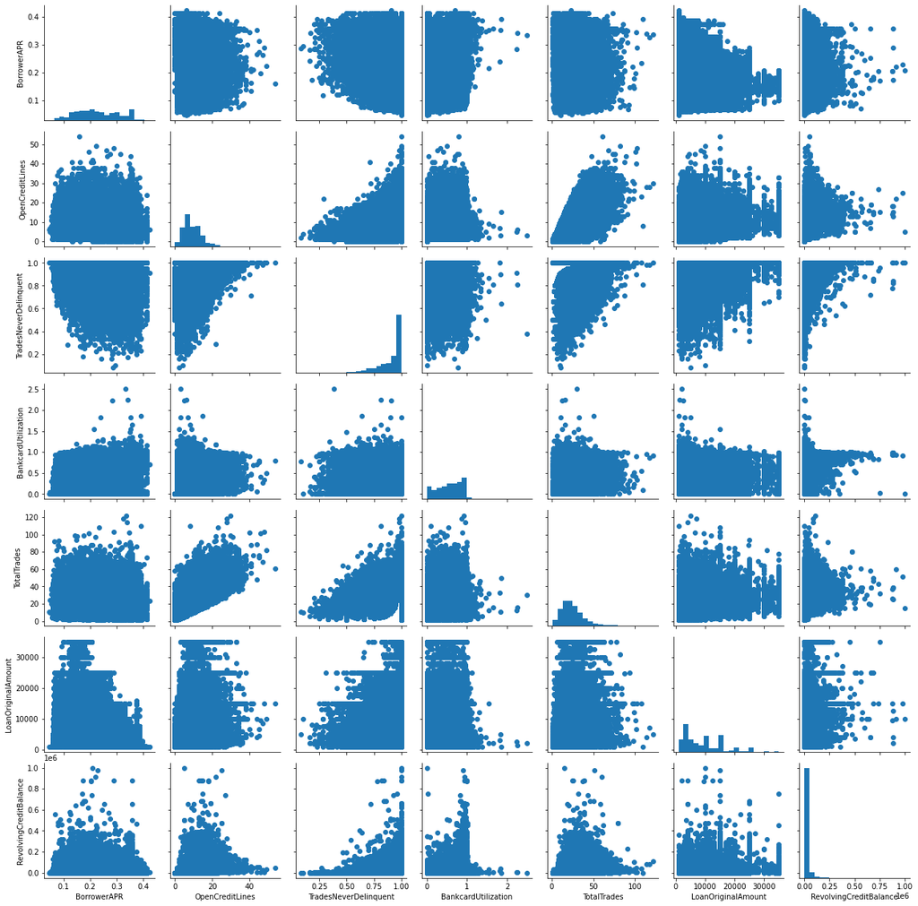

```python
# Plot matrix of numeric data
g = sns.PairGrid(data=loans, vars=num_vars)
g = g.map_offdiag(plt.scatter)
g.map_diag(plt.hist, bins=20);
```

We see slight correlation between **`OpenCreditLines`** and `TradesNeverDelinquent` as well as with `RevolvingCreditBalance` but a stronger correlation with `TotalTrades` which makes sense because more open credit lines means more credit accessed.

Now, let us look at the interaction between the categorical features starting with the ordinal features.

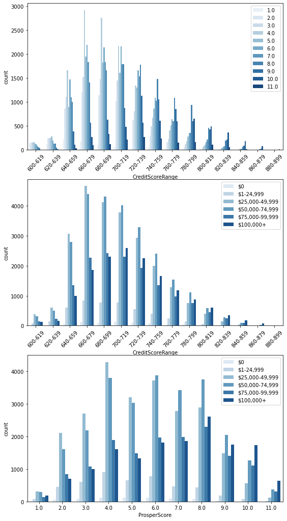

```python
# First, let us create subplots for the three ordinal variables
plt.figure(figsize=(9,18))
plt.subplot(3, 1, 1)
sns.countplot(data=loans, x='CreditScoreRange', hue='ProsperScore', palette='Blues')
plt.xticks(rotation=45)
plt.legend(loc=1);

plt.subplot(3, 1, 2)
sns.countplot(data=loans, x='CreditScoreRange', hue='IncomeRange', palette='Blues')
plt.xticks(rotation=45)
plt.legend(loc=1);

plt.subplot(3, 1, 3)
sns.countplot(data=loans, x='ProsperScore', hue='IncomeRange', palette='Blues')
plt.legend(loc=1);
```

Now, let's create subplots to examine the four nominal features.

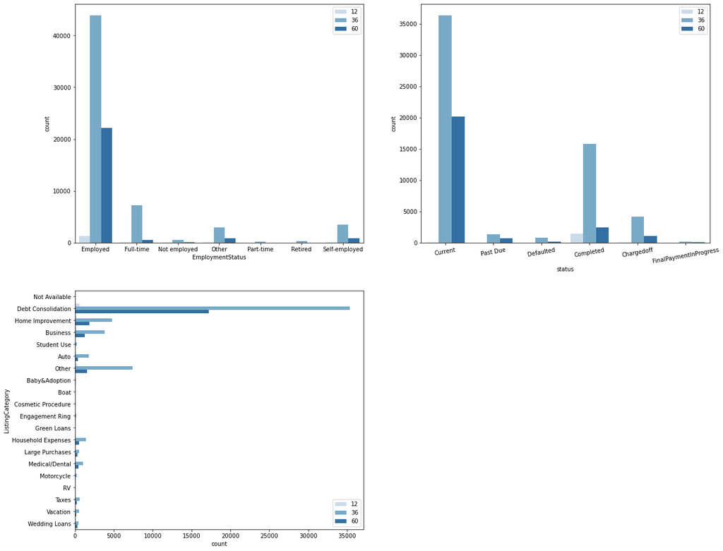

```python
#To avoid overplotting, let's plot Term against the other nominal features
plt.figure(figsize=(20,17))
plt.subplot(2, 2, 1)
sns.countplot(data=loans, x='EmploymentStatus', hue='Term', palette='Blues')
plt.legend(loc=1);

plt.subplot(2, 2, 2)
sns.countplot(data=loans, x='status', hue='Term', palette='Blues')
plt.xticks(rotation=10)
plt.legend(loc=1);

plt.subplot(2, 2, 3)
listing_order = loans.ListingCategory.value_counts().index
sns.countplot(data=loans, y='ListingCategory', hue='Term', palette='Blues')
plt.legend(loc=4);
```

Let us see how Listing Category, Employment Status and Loan status correlate.

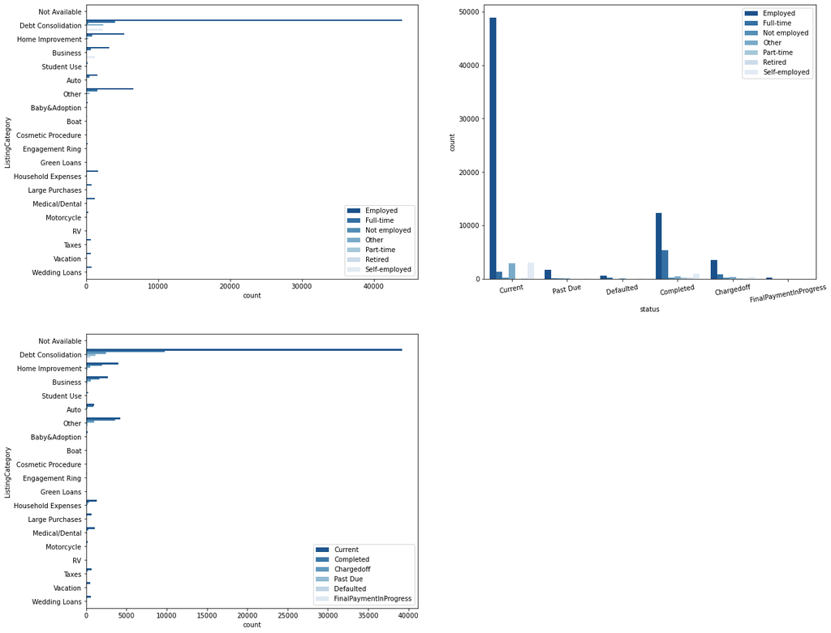

```python
# Now let's plot the remaining nominal features
plt.figure(figsize=(20,17))
plt.subplot(2, 2, 1)
sns.countplot(data=loans, y='ListingCategory', hue='EmploymentStatus', palette='Blues_r')
plt.legend(loc=4);

plt.subplot(2, 2, 2)
sns.countplot(data=loans, x='status', hue='EmploymentStatus', palette='Blues_r')
plt.xticks(rotation=10)
plt.legend(loc=1);

plt.subplot(2, 2, 3)
loan_status_order = loans.status.value_counts().index
sns.countplot(data=loans, y='ListingCategory', hue='status', hue_order=loan_status_order, palette='Blues_r')
plt.legend(loc=4);
```

Finally, let us see how the nominal features interact with the ordinal features. We would examine credit score against the nominal features first.

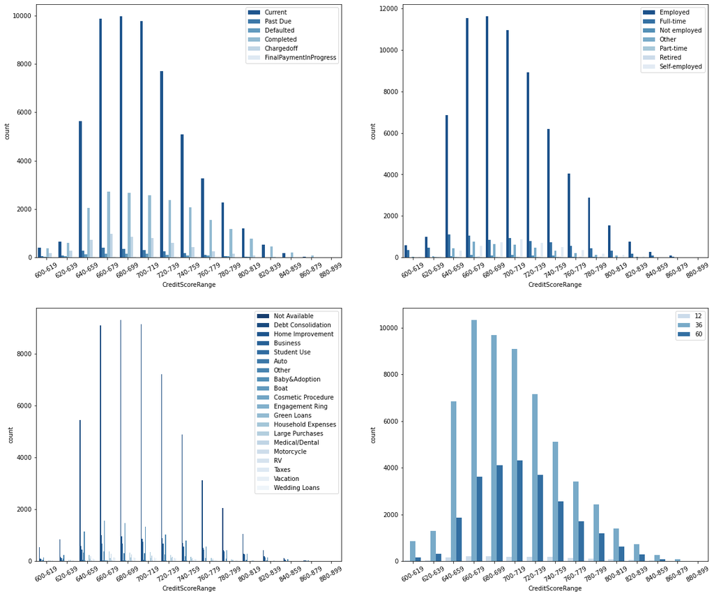

```python
# First let's plot CreditScore against the nominal variables
plt.figure(figsize=(20,17))
plt.subplot(2, 2, 1)
sns.countplot(data=loans, x='CreditScoreRange', hue='status', palette='Blues_r')
plt.xticks(rotation=30)
plt.legend(loc=1);

plt.subplot(2, 2, 2)
sns.countplot(data=loans, x='CreditScoreRange', hue='EmploymentStatus', palette='Blues_r')
plt.xticks(rotation=30)
plt.xticks(rotation=30)
plt.legend(loc=1);

plt.subplot(2, 2, 3)
sns.countplot(data=loans, x='CreditScoreRange', hue='ListingCategory', palette='Blues_r')
plt.xticks(rotation=30)
plt.legend(loc=1);

plt.subplot(2, 2, 4)
sns.countplot(data=loans, x='CreditScoreRange', hue='Term', palette='Blues')
plt.xticks(rotation=30)
plt.legend(loc=1);
```

Now let us examine how Prosper score correlates with the nominal variables.

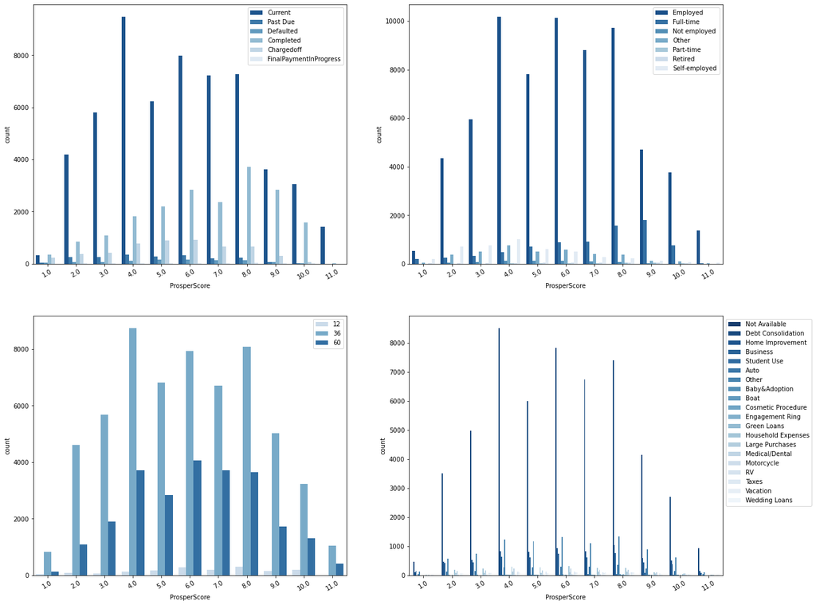

```python
# Next let's plot ProsperScore against the nominal variables
plt.figure(figsize=(20,17))
plt.subplot(2, 2, 1)
sns.countplot(data=loans, x='ProsperScore', hue='status', palette='Blues_r')
plt.xticks(rotation=30)
plt.legend(loc=1);

plt.subplot(2, 2, 2)
sns.countplot(data=loans, x='ProsperScore', hue='EmploymentStatus', palette='Blues_r')
plt.xticks(rotation=30)
plt.xticks(rotation=30)
plt.legend(loc=1);

plt.subplot(2, 2, 3)
sns.countplot(data=loans, x='ProsperScore', hue='Term', palette='Blues')
plt.xticks(rotation=30)
plt.legend(loc=1);

plt.subplot(2, 2, 4)
sns.countplot(data=loans, x='ProsperScore', hue='ListingCategory', palette='Blues_r')
plt.xticks(rotation=30)
plt.legend(bbox_to_anchor=(1,1));
```

Lastly, let us examine how Income range correlates with the nominal variables.

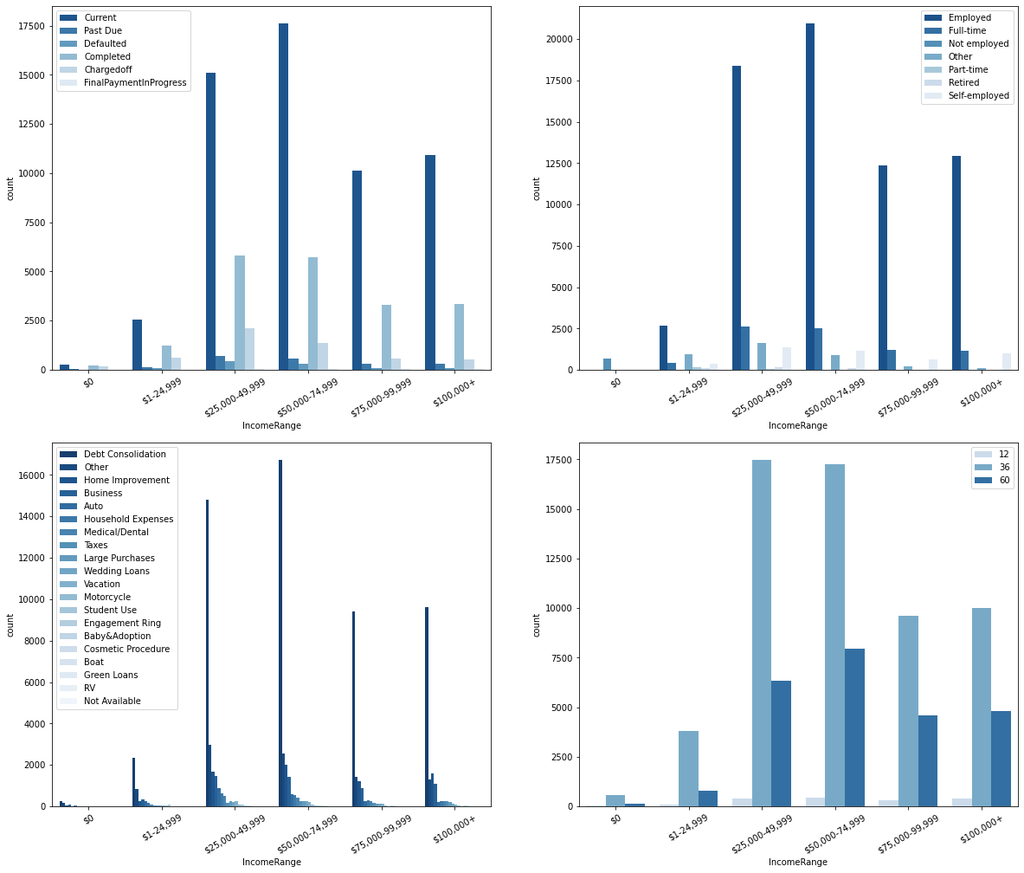

```python
# Let's plot IncomeRange against the nominal variables
plt.figure(figsize=(20,17))
plt.subplot(2, 2, 1)
sns.countplot(data=loans, x='IncomeRange', hue='status', palette='Blues_r')
plt.xticks(rotation=30)
plt.legend(loc=2);

plt.subplot(2, 2, 2)
sns.countplot(data=loans, x='IncomeRange', hue='EmploymentStatus', palette='Blues_r')
plt.xticks(rotation=30)
plt.xticks(rotation=30)
plt.legend(loc=1);

plt.subplot(2, 2, 3)
listing_order = loans.ListingCategory.value_counts().index
sns.countplot(data=loans, x='IncomeRange', hue='ListingCategory', hue_order=listing_order, palette='Blues_r')
plt.xticks(rotation=30)
plt.legend(loc=2);

plt.subplot(2, 2, 4)
sns.countplot(data=loans, x='IncomeRange', hue='Term', palette='Blues')
plt.xticks(rotation=30)
plt.legend(loc=1);
```

We see also that majority of the loans are *active* and were taken out for *debt consolidation* for a period of *36months*, mostly by *employed* folks with credit scores between 660-719.

Moving on, let us see how the numeric variables interact with the categorical variables. First, let us see how some nominal variables are correlated with the numeric variables.

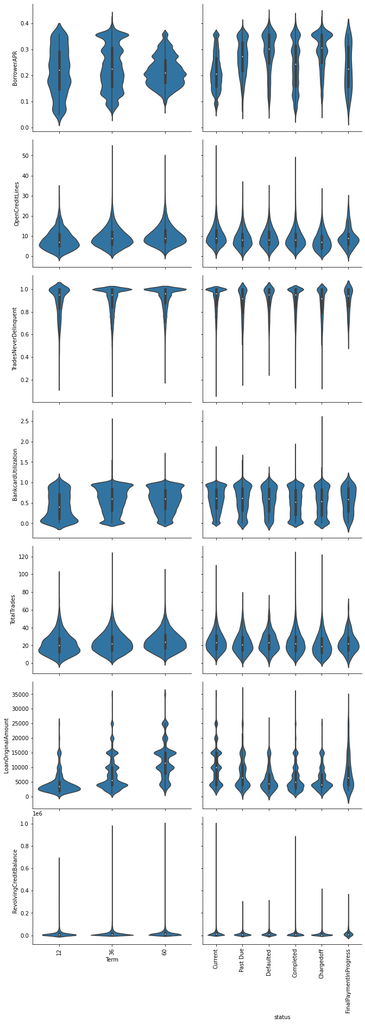

```python
# Plot nominal type data 'Term' & 'LoanStatus' against the numeric variables
def violingrid(x, y, **kwargs):
    """ Quick hack for creating violin plots using Seaborn's PairGrid. """
    base_color = sns.color_palette()[0]
    sns.violinplot(x, y, color=base_color)
    plt.xticks(rotation=90)

g = sns.PairGrid(data=loans, x_vars=['Term', 'status'], y_vars=num_vars, height=3.6, aspect=1.3)
g.map(violingrid);
```

More nominal variables paired against numeric variables.

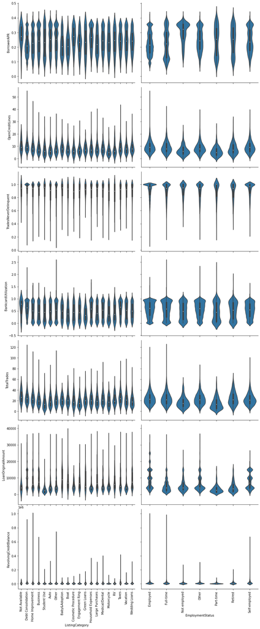

```python
# Plot nominal type data 'EmploymentStatus' & 'ListingCategory' against the numeric variables
g = sns.PairGrid(data=loans, x_vars=['ListingCategory', 'EmploymentStatus'], y_vars=num_vars, height=4, aspect=1.5)
g.map(violingrid);
```

How do the ordinal variables interact with the numeric variables?

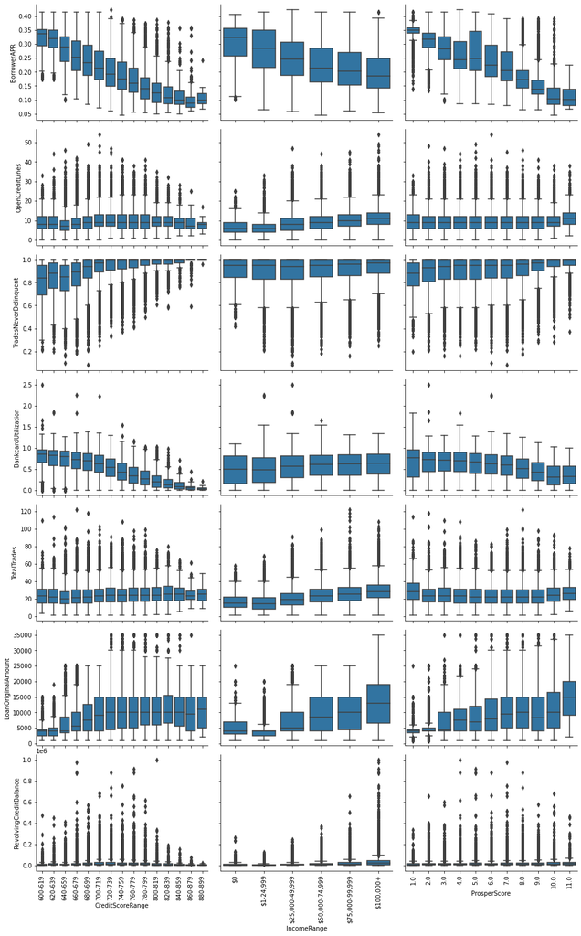

```python
# Plot ordinal type data features against the numeric variables
def boxgrid(x, y, **kwargs):
    base_color = sns.color_palette()[0]
    sns.boxplot(x, y, color=base_color)
    plt.xticks(rotation=90)

g = sns.PairGrid(data=loans, x_vars=['CreditScoreRange', 'IncomeRange', 'ProsperScore'], y_vars=num_vars, height=3, aspect=1.5)
g.map(boxgrid);
```

The relationship between the numeric features and nominal categorical features are random at best except for `Term` which appears to have a positive relationship with most of the numeric features. The ordinal variables on the other hand have clearer positive or negative correlation with the numeric features.

### Talk about some of the relationships you observed in this part of the investigation. How did the feature(s) of interest vary with other features in the dataset?

> The medians of current loans and debt consolidation loans are low in BorrowerAPR, although current loans appeared to be the highest across other numeric features. We see that employed borrowers took larger amounts of loan, however, the unemployed borrowers took out loans with the highest Annual Percentage Rate.

## Multivariate Exploration

> In this section , I will expand my investigation by exploring relationships between three or more variables, but my main focus would be analyzing how other variables in the data play into the relationship between the main features of interest: `BorrowerAPR` and `CreditScoreRange`.

First, let us plot some nominal features against our main features of interest to see their correlation.

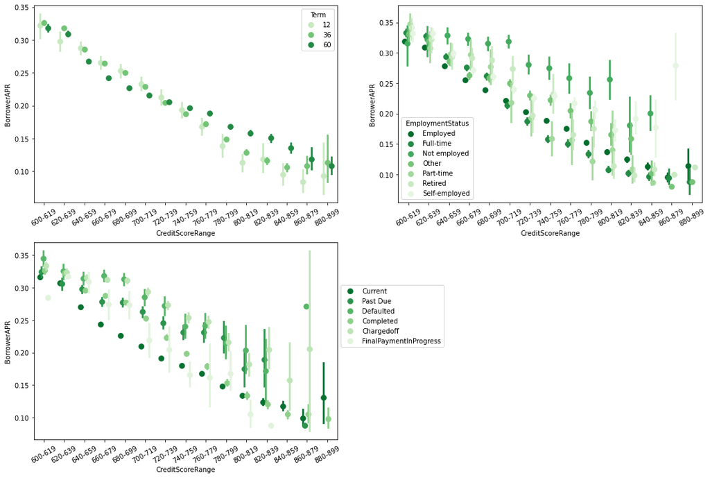

```python
# Plot 'Term', 'EmploymentStatus' & 'LoanStatus' against the main features of interest
plt.figure(figsize=(18,12))
plt.subplot(2, 2, 1)
sns.pointplot(data=loans, x='CreditScoreRange', y='BorrowerAPR', hue='Term', palette='Greens',
                  linestyles='', dodge=0.4)
plt.xticks(rotation=30);

plt.subplot(2, 2, 2)
sns.pointplot(data=loans, x='CreditScoreRange', y='BorrowerAPR', hue='EmploymentStatus', palette='Greens_r',
                  linestyles='', dodge=0.4)
plt.xticks(rotation=30);

plt.subplot(2, 2, 3)
sns.pointplot(data=loans, x='CreditScoreRange', y='BorrowerAPR', hue='status', palette='Greens_r',
                  linestyles='', dodge=0.4)
plt.xticks(rotation=30)
plt.legend(bbox_to_anchor=(1,0.8));
```

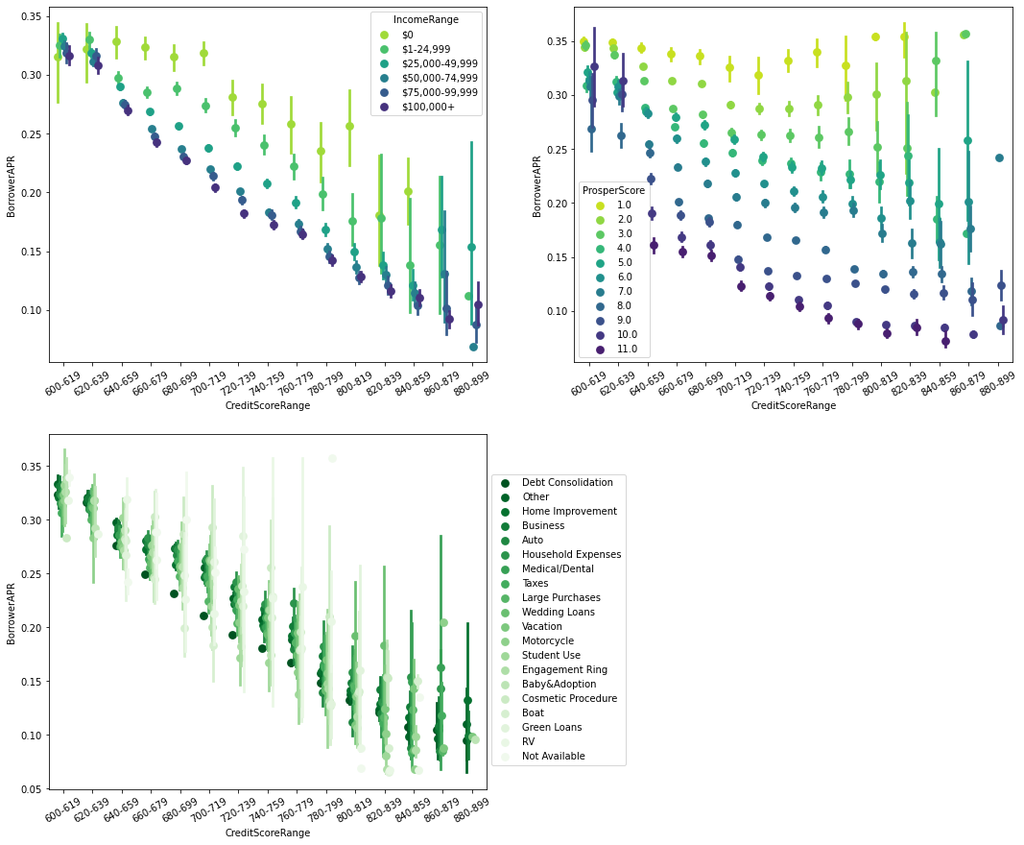

```python
# Next let's plot 'IncomeRange', 'ProsperScore' & 'ListingCategory' against the main features of interest
plt.figure(figsize=(18,15))
plt.subplot(2, 2, 1)
sns.pointplot(data=loans, x='CreditScoreRange', y='BorrowerAPR', hue='IncomeRange', palette='viridis_r',
                  linestyles='', dodge=0.4)
plt.xticks(rotation=30);

plt.subplot(2, 2, 2)
sns.pointplot(data=loans, x='CreditScoreRange', y='BorrowerAPR', hue='ProsperScore', palette='viridis_r',
                  linestyles='', dodge=0.4)
plt.xticks(rotation=30);

plt.subplot(2, 2, 3)
listing_order = loans.ListingCategory.value_counts().index
sns.pointplot(data=loans, x='CreditScoreRange', y='BorrowerAPR', hue='ListingCategory', hue_order=listing_order,
              palette='Greens_r', linestyles='', dodge=0.4)
plt.xticks(rotation=30)
plt.legend(bbox_to_anchor=(1,0.9));
```

Finally, let us examine the correlation between the numeric variables and the main features of interest.

```python
# Define a function to set jitters
def jitter(ax):
    """ To offset datapoints and create jitters. """
    offsets = ax.get_offsets()
    offsets[:, 0] += np.random.uniform(-0.2, 0.2, offsets.shape[0]) #jitter along the x-axis with a precision of 0.2
    ax.set_offsets(offsets)
```

```python
# Define a function to assign axes labels and x-axis limits
def plot(plt, xlabel, ylabel):
    """Quick hack for assigning labels """
    plt.xlabel(xlabel)
    plt.ylabel(ylabel)
    xmin, xmax = plt.xlim()
    plt.xlim(xmin-0.01, xmax+0.01) # make room for jitters
    plt.xticks(rotation=30)
```

```python
# Create dataframe with ascending order of credit scores
credit = loans.sort_values('CreditScoreRange')
```

To begin, let us look at the relationship between OpenCreditLines, TradesNeverDelinquent, TotalTrades and the main features of interest.

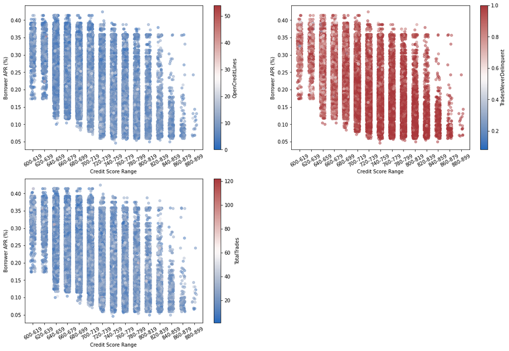

```python
# Plot 'OpenCreditLines', 'TradesNeverDelinquent' & 'TotalTrades' against the main features of interest
axes = plt.figure(figsize=(18, 12))
plt.subplot(2, 2, 1)
ax = plt.scatter(data=credit, x='CreditScoreRange', y='BorrowerAPR', c='OpenCreditLines', s=25, cmap='vlag', alpha=.5);
jitter(ax)
plot(plt, 'Credit Score Range', 'Borrower APR (%)')
# Plot colorbar without transparency effect and add labels
norm = plt.Normalize(credit['OpenCreditLines'].min(), credit['OpenCreditLines'].max())
sm = plt.cm.ScalarMappable(cmap='vlag', norm=norm)
sm.set_array([])
ax.figure.colorbar(sm).set_label('OpenCreditLines')

plt.subplot(2, 2, 2)
ax = plt.scatter(data=credit, x='CreditScoreRange', y='BorrowerAPR', c='TradesNeverDelinquent', s=25, cmap='vlag', alpha=.5);
jitter(ax)
plot(plt, 'Credit Score Range', 'Borrower APR (%)')
norm = plt.Normalize(credit['TradesNeverDelinquent'].min(), credit['TradesNeverDelinquent'].max())
sm = plt.cm.ScalarMappable(cmap='vlag', norm=norm)
sm.set_array([])
ax.figure.colorbar(sm).set_label('TradesNeverDelinquent');

plt.subplot(2, 2, 3)
ax = plt.scatter(data=credit, x='CreditScoreRange', y='BorrowerAPR', c='TotalTrades', s=25, cmap='vlag', alpha=.5);
jitter(ax)
plot(plt, 'Credit Score Range', 'Borrower APR (%)')
norm = plt.Normalize(credit['TotalTrades'].min(), credit['TotalTrades'].max())
sm = plt.cm.ScalarMappable(cmap='vlag', norm=norm)
sm.set_array([])
ax.figure.colorbar(sm).set_label('TotalTrades');
```

There seems to be no systematic relationship between these numeric variables and our features of interest, however, for the deliquent trades, we see that just a few number of credit profiles have had delinquent trades and it appears to increase with lower credit scores. Lastly, let us examine the relationship between BankcardUtilization, LoanOriginalAmount, RevolvingCreditBalance and the main features of interest.

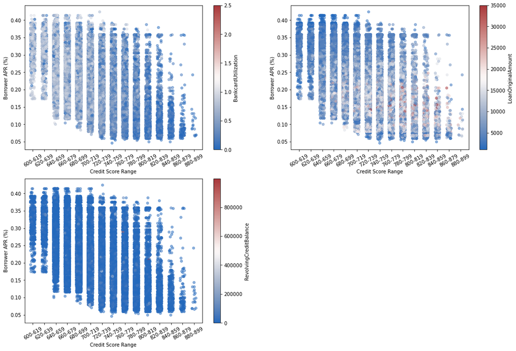

```python
# Plot 'BankcardUtilization', 'LoanOriginalAmount' & 'RevolvingCreditBalance' against the main features of interest
plt.figure(figsize=(18, 12))
plt.subplot(2, 2, 1)
ax = plt.scatter(data=credit, x='CreditScoreRange', y='BorrowerAPR', c='BankcardUtilization', s=25, cmap='vlag', alpha=.5);
jitter(ax)
plot(plt, 'Credit Score Range', 'Borrower APR (%)')
norm = plt.Normalize(credit['BankcardUtilization'].min(), credit['BankcardUtilization'].max())
sm = plt.cm.ScalarMappable(cmap='vlag', norm=norm)
sm.set_array([])
ax.figure.colorbar(sm).set_label('BankcardUtilization')

plt.subplot(2, 2, 2)
ax = plt.scatter(data=credit, x='CreditScoreRange', y='BorrowerAPR', c='LoanOriginalAmount', s=25, cmap='vlag', alpha=.5);
jitter(ax)
plot(plt, 'Credit Score Range', 'Borrower APR (%)')
norm = plt.Normalize(credit['LoanOriginalAmount'].min(), credit['LoanOriginalAmount'].max())
sm = plt.cm.ScalarMappable(cmap='vlag', norm=norm)
sm.set_array([])
ax.figure.colorbar(sm).set_label('LoanOriginalAmount');

plt.subplot(2, 2, 3)
ax = plt.scatter(data=credit, x='CreditScoreRange', y='BorrowerAPR', c='RevolvingCreditBalance', s=25, cmap='vlag', alpha=.5);
jitter(ax)
plot(plt, 'Credit Score Range', 'Borrower APR (%)')
norm = plt.Normalize(credit['RevolvingCreditBalance'].min(), credit['RevolvingCreditBalance'].max())
sm = plt.cm.ScalarMappable(cmap='vlag', norm=norm)
sm.set_array([])
ax.figure.colorbar(sm).set_label('RevolvingCreditBalance');
```

## Conclusions

The exploration was structured from simple univariate relationships to multivariate relationships to summarize the characteristics of features that can affect the annual percentage rate (APR) and outcome of a loan. To summarize our exploratory analysis-

### Limitations

In spite of the fact that our exploratory analysis gave us a lot of insightful visualizations, building predictive models would provide clearer renderings of the interaction between features and more definitive insights into the data.